# Prévision de Séries Temporelles avec WNN

```r
library(OlivierBorot)
library(forecast)
library(ggplot2)
```

# Introduction

Le package **OlivierBorot** implémente l’algorithme **Weighted Nearest Neighbors (WNN)** pour la prévision de séries temporelles, tel que décrit dans Talavera-Llames et al. (2016). Please note there is also an English version of this vignette available here, named “WNN_EN.Rmd”

## Vue d’ensemble de l’algorithme

L’algorithme WNN est une méthode non-paramétrique qui :

1. **Extrait** les `w` dernières observations comme motif de référence
2. **Recherche** dans les données historiques des motifs similaires
3. **Identifie** les `k` plus proches voisins en utilisant la distance euclidienne
4. **Combine** les valeurs futures suivant chaque voisin avec une pondération inverse au carré de la distance

### Formulation Mathématique

Étant donné une série temporelle avec des valeurs jusqu’à $c_i$, on souhaite prédire les $h$ prochaines valeurs.

La fenêtre de référence est :
$$CC_i =
[c_{i-w+1}, c_{i-w+2}, \ldots, c_i]$$

La distance euclidienne entre les motifs :
$$dist(i,j) = ||CC_i - CC_j||$$

La prévision pondérée :
$$\hat{C}_i =
\frac{1}{\sum_{j=1}^{k} \alpha_j} \sum_{j=1}^{k} \alpha_j
C_{q_j}$$

où $\alpha_j = \frac{1}{dist(CC_{q_j}, CC_i)^2}$

# Exemple : Jeu de Données AirPassengers

Nous utiliserons le jeu de données classique `AirPassengers` pour démontrer l’algorithme WNN.

## Exploration des Données

```r
# Charger le jeu de données AirPassengers
data(AirPassengers)

# Informations de base
cat("Jeu de données : AirPassengers\n")
```

```
#> Jeu de données : AirPassengers
```

```r
cat("Longueur :", length(AirPassengers), "observations\n")
```

```
#> Longueur : 144 observations
```

```r
cat("Fréquence :", frequency(AirPassengers), "(mensuelle)\n")
```

```
#> Fréquence : 12 (mensuelle)
```

```r
cat("Période :", paste(start(AirPassengers), collapse = "-"), "à",
    paste(end(AirPassengers), collapse = "-"), "\n")
```

```
#> Période : 1949-1 à 1960-12
```

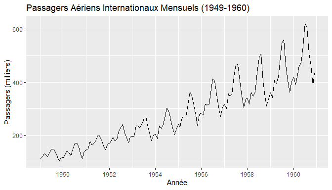

```r
# Visualiser les données
autoplot(AirPassengers) +
  ggtitle("Passagers Aériens Internationaux Mensuels (1949-1960)") +
  xlab("Année") +
  ylab("Passagers (milliers)")
```

## Séparation Train-Test

Nous utiliserons les 132 premiers mois pour l’entraînement et les 12 derniers mois pour le test.

```r
# Séparer les données
train_end <- c(1959, 12)
train <- window(AirPassengers, end = train_end)
test <- window(AirPassengers, start = c(1960, 1))

cat("Ensemble d'entraînement :", length(train), "observations\n")
```

```
#> Ensemble d'entraînement : 132 observations
```

```r
cat("Ensemble de test :", length(test), "observations\n")
```

```
#> Ensemble de test : 12 observations
```

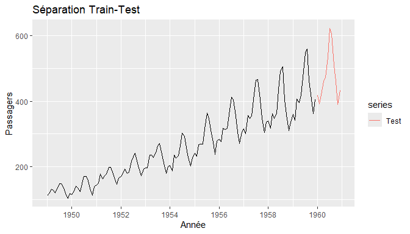

```r
# Visualiser la séparation
autoplot(train) +
  autolayer(test, series = "Test") +
  ggtitle("Séparation Train-Test") +
  xlab("Année") +
  ylab("Passagers")
```

## Entraînement et Prédiction du Modèle WNN

```r
# Créer le modèle WNN
# - horizon = 12 (prédire 12 mois)
# - window = 24 (utiliser 24 mois pour la correspondance de motifs)
# - k = 5 (utiliser 5 plus proches voisins)
wnn_model <- WNN$new(horizon = 12, window = 24, k = 5)

# Afficher les paramètres du modèle
print(wnn_model)
```

```
#> WNN Model
#> ---------
#> Horizon (h): 12
#> Window (w):  24
#> Neighbors (k): 5
#> Status: Not fitted
```

```r
# Entraîner et prédire
wnn_forecast <- wnn_model$fit_predict(train)

# Afficher le résumé complet
wnn_model$summary()
```

```
#> =======================================================
#>            WNN MODEL - COMPLETE SUMMARY
#> =======================================================
#>
#> >> HYPERPARAMETERS
#>    Horizon (h)     : 12 values to predict
#>    Window (w)      : 24 values for pattern matching
#>    Neighbors (k)   : 5 nearest neighbors
#>
#> >> STATUS: Model fitted
#>
#> >> ORIGINAL DATA
#>    Length          : 132 observations
#>    Min             : 104
#>    Max             : 559
#>    Mean            : 262.4924
#>    Std Dev         : 106.6258
#>    Frequency       : 12
#>    Start           : 1949-1
#>    End             : 1959-12
#>
#> >> NEAREST NEIGHBORS
#>    Distances       : 284.7244, 351.7698, 354.9958, 180.5132, 288.562
#>    Weights (alpha) : 0.1736, 0.1137, 0.1117, 0.4319, 0.169
#>
#> >> FORECAST (12 values)
#>    Start           : 1960-1
#>    Frequency       : 12
#>    Values          :
#>           Jan      Feb      Mar      Apr      May      Jun      Jul      Aug
#> 1960 345.1688 343.1199 371.0264 382.0721 399.8636 446.7056 507.6597 522.7384
#>           Sep      Oct      Nov      Dec
#> 1960 462.5560 397.2411 357.8446 370.3125
#>
#> =======================================================
```

## Visualisation des Résultats

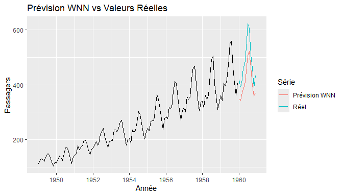

```r
# Comparer prévision et valeurs réelles
autoplot(train) +
  autolayer(test, series = "Réel") +
  autolayer(wnn_forecast, series = "Prévision WNN") +
  ggtitle("Prévision WNN vs Valeurs Réelles") +
  xlab("Année") +
  ylab("Passagers") +
  guides(colour = guide_legend(title = "Série"))
```

## Précision des Prévisions

```r
# Calculer les métriques de précision
errors <- test - wnn_forecast

# Erreur Absolue Moyenne (MAE)
mae <- mean(abs(errors))

# Racine de l'Erreur Quadratique Moyenne (RMSE)
rmse <- sqrt(mean(errors^2))

# Erreur Absolue Moyenne en Pourcentage (MAPE)
mape <- mean(abs(errors / test)) * 100

cat("Métriques de Précision des Prévisions :\n")
```

```
#> Métriques de Précision des Prévisions :
```

```r
cat("---------------------------------------\n")
cat("MAE  :", round(mae, 2), "\n")
```

```
#> MAE  : 67.31
```

```r
cat("RMSE :", round(rmse, 2), "\n")
```

```
#> RMSE : 70.69
```

```r
cat("MAPE :", round(mape, 2), "%\n")
```

```
#> MAPE : 13.94 %
```

# Comparaison avec d’Autres Méthodes

Comparons WNN avec des méthodes de prévision traditionnelles.

```r
# Modèle ETS
ets_model <- ets(train)
ets_forecast <- forecast(ets_model, h = 12)

# Modèle ARIMA
arima_model <- auto.arima(train)
arima_forecast <- forecast(arima_model, h = 12)

# Calculer le RMSE pour chaque méthode
rmse_wnn <- sqrt(mean((test - wnn_forecast)^2))
rmse_ets <- sqrt(mean((test - ets_forecast$mean)^2))
rmse_arima <- sqrt(mean((test - arima_forecast$mean)^2))

# Créer le tableau de comparaison
comparison <- data.frame(
  Methode = c("WNN (k=5, w=24)", "ETS", "ARIMA"),
  RMSE = round(c(rmse_wnn, rmse_ets, rmse_arima), 2)
)

print(comparison)
```

```
#>           Methode  RMSE
#> 1 WNN (k=5, w=24) 70.69
#> 2             ETS 27.40
#> 3           ARIMA 23.93
```

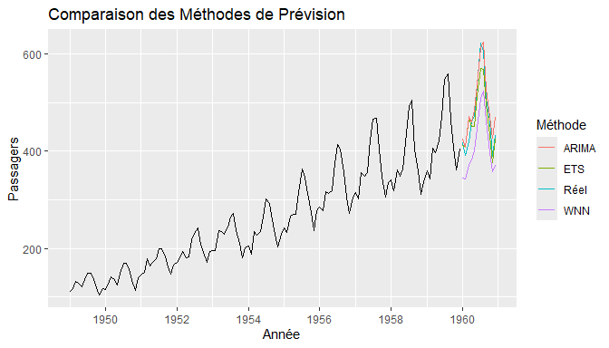

```r
# Comparaison visuelle
autoplot(train) +
  autolayer(test, series = "Réel") +
  autolayer(wnn_forecast, series = "WNN") +
  autolayer(ets_forecast$mean, series = "ETS") +
  autolayer(arima_forecast$mean, series = "ARIMA") +
  ggtitle("Comparaison des Méthodes de Prévision") +
  xlab("Année") +
  ylab("Passagers") +
  guides(colour = guide_legend(title = "Méthode"))
```

# Sensibilité aux Hyperparamètres

Explorons comment les différents hyperparamètres affectent la prévision.

## Effet de k (Nombre de Voisins)

```r
k_values <- c(1, 3, 5, 7, 10)
results <- data.frame(k = integer(), RMSE = numeric())

for (k in k_values) {
  model <- WNN$new(horizon = 12, window = 24, k = k)
  pred <- model$fit_predict(train)
  rmse <- sqrt(mean((test - pred)^2))
  results <- rbind(results, data.frame(k = k, RMSE = rmse))
}

print(results)
```

```
#>    k     RMSE
#> 1  1 50.70832
#> 2  3 62.83187
#> 3  5 70.68636
#> 4  7 72.94597
#> 5 10 77.53678
```

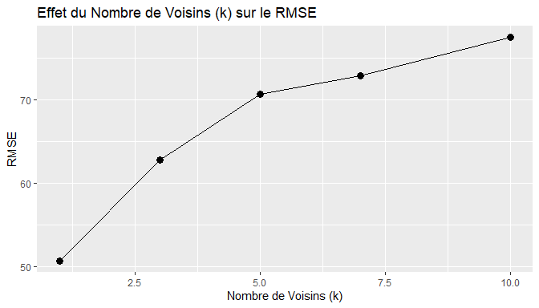

```r
ggplot(results, aes(x = k, y = RMSE)) +
  geom_line() +
  geom_point(size = 3) +
  ggtitle("Effet du Nombre de Voisins (k) sur le RMSE") +
  xlab("Nombre de Voisins (k)") +
  ylab("RMSE")
```

## Effet de la Taille de Fenêtre (w)

```r
window_values <- c(12, 18, 24, 36, 48)
results_w <- data.frame(window = integer(), RMSE = numeric())

for (w in window_values) {
  model <- WNN$new(horizon = 12, window = w, k = 5)
  pred <- model$fit_predict(train)
  rmse <- sqrt(mean((test - pred)^2))
  results_w <- rbind(results_w, data.frame(window = w, RMSE = rmse))
}

print(results_w)
```

```
#>   window     RMSE
#> 1     12 75.34566
#> 2     18 72.10221
#> 3     24 70.68636
#> 4     36 66.57569
#> 5     48 66.56919
```

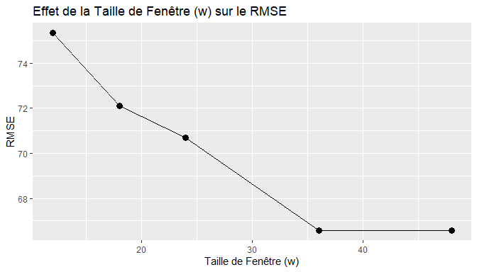

```r
ggplot(results_w, aes(x = window, y = RMSE)) +
  geom_line() +
  geom_point(size = 3) +
  ggtitle("Effet de la Taille de Fenêtre (w) sur le RMSE") +
  xlab("Taille de Fenêtre (w)") +
  ylab("RMSE")
```

# Conclusion

L’algorithme **WNN** offre une approche simple mais efficace pour la prévision de séries temporelles :

**Points forts :**

- Facile à comprendre et à implémenter
- Aucune hypothèse sur la distribution des données
- Fonctionne bien avec des motifs récurrents
- Peu d’hyperparamètres à régler

**Points à considérer :**

- Le coût computationnel augmente avec la longueur de la série
- Nécessite suffisamment de données historiques
- La performance dépend de la similarité des motifs dans les données

## Références

Talavera-Llames, R.L., Pérez-Chacón, R., Martínez-Ballesteros, M., Troncoso, A., Martínez-Álvarez, F. (2016). **A Nearest Neighbours-Based Algorithm for Big Time Series Data Forecasting**. In: Hybrid Artificial Intelligent Systems. HAIS 2016. Lecture Notes in Computer Science, vol 9648. Springer, Cham.